# Reproducable Week 2 Assignment

Yunhui Wang

July 30, 2017

## Loading and preprocessing the data

```r
if(!file.exists("getdata-projectfiles-UCI HAR Dataset.zip")) {
        temp <- tempfile()
        download.file("https://d396qusza40orc.cloudfront.net/repdata%2Fdata%2Factivity.zip",temp)
        unzip(temp)
        unlink(temp)}

df<-read.csv(file='activity.csv')
```

## Part I: What is mean total number of steps taken per day?

#### 1.Calculate the total number of steps taken per day

```r
df_s_d<-aggregate(df$steps, list(df$date), sum, na.rm=TRUE)
names(df_s_d)=c("date","total")
```

#### 2.Make a histogram of the total number of steps taken each day.Calculate and report the mean and median of the total number of steps taken per day

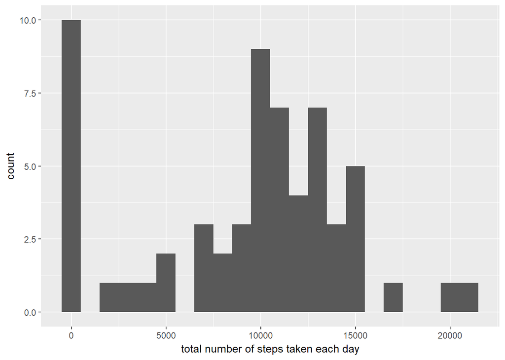

```r
qplot(df_s_d$total, geom="histogram",binwidth = 1000,xlab="total number of steps taken each day")
```

```r
mean<-round(mean(df_s_d$total),digits=2)
median<-median(df_s_d$total)
```

**The mean and median of the total number of steps taken per day is 9354.23 and 10395 respectively.**

## Part II: What is the average daily activity pattern?

#### 1.Make a time series plot (i.e. type = “l”) of the 5-minute interval (x-axis) and the average number of steps taken, averaged across all days (y-axis)

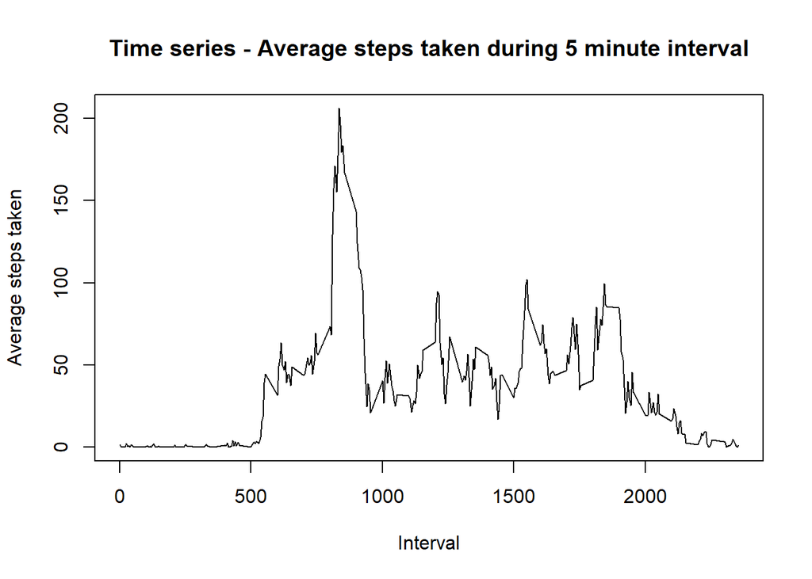

```r
df_interval<-aggregate(df$steps, list(df$interval), mean, na.rm=TRUE)
names(df_interval)=c("interval","steps")

plot(df_interval$interval, df_interval$steps,
     type="l",
     xlab="Interval",
     ylab="Average steps taken",
     main="Time series - Average steps taken during 5 minute interval")
```

#### 2.Which 5-minute interval, on average across all the days in the dataset, contains the maximum number of steps?

```r
max<-df_interval$interval[which.max(df_interval$steps)]
```

**The 5 minutes interval that contains the maximum number of steps? is 835.**